##### Specification of recombination landscape and modifier loci.

I will start with a simple model of recombination on a chromosome that is 1 Morgan long (i.e. an average of one crossover per meiosis). The number of loci contributing to the trait are specified. Each locus has two alleles: `0` resulting in no change in phenotype, and `1` that results in an increase in phenotype by one unit (NB. Specifying the units in this way is built into the function `simPopulationResponse`)

```r
n.loci <- 100   # The number of loci contributing to the trait
```

The function then requires information on the recombination fraction between loci, as well as the allele frequencies of the `1` alleles at each locus. Lets make a map for a 1 Morgan chromosome (total length 100cM) with equal recombination probabilities between loci. If we have 100 loci then we have a mean recombination fraction between loci of 0.01. Let’s also specify equal allele frequencies at each locus.

```r
map.1  <- rep(1/n.loci, n.loci)
freq.1 <- rep(0.5, n.loci)
```

We can simulation the population for a specified number of generations, and the number of founder haplotypes from which generation 1 are selected. At present, the starting haplotype pool are sampled at random based on allele frequences. We can also specify the number of haplotypes segregating in the founder population:

```r
generations <- 100
n.found.hap <- 100
```

The function `simPopulationResponse` will use this information to simulate a population using the above parameters as so. NB. map.list must take a list, so input `list(map.1)` - this will become clearer later.

NB. What does this function do?

```r
sim.1 <- simPopulationResponse(n.found.hap = n.found.hap,
                               n.loci = n.loci,
                               n.f = n.females, n.m = n.males,
                               map.list = list(map.1),
                               allele.freqs = freq.1,
                               f.RS = n.offspring,
                               sel.thresh.f = female.sel.thresh,
                               sel.thresh.m = male.sel.thresh,
                               modifier.found.freq = 0,
                               n.generations = generations,
                               force.equal.male.success = T,
                               force.equal.sex = T,
                               progressBar = F)
```

The `sim.1` object contains the slot `results`, which is a list of data frames containing information on each simulated individual in each generation. Headers indicate the generation, ID, mother and father IDs from the previous generation, sex (1 = male, 2 = female), the phenotypic value, the genotype of the individual for a modifier locus (this will be specified later) and whether or not that individual reproduced:

```r
# example from generation three

head(sim.1$results[[3]])
```

```
##   GEN ID MOTHER FATHER SEX PHENO modifier Bred
## 1   2  1      2     55   1    95        1    0
## 2   2  2      2     51   2    98        1    1
## 3   2  3      4     65   1   111        1    1
## 4   2  4      4     97   2    94        1    1
## 5   2  5      6     27   1   101        1    0
## 6   2  6      6     97   2   116        1    1
```

The list can be condensed into a `data.table`. Let’s examine what happens over the course of the simulation:

```r
sim.1.res <- rbindlist(sim.1$results)

sim.1.res
```

```
##        GEN  ID MOTHER FATHER SEX PHENO modifier Bred
##     1:   0   1     NA     NA   1    82        1    0
##     2:   0   2     NA     NA   1    83        1    0
##     3:   0   3     NA     NA   1    89        1    0
##     4:   0   4     NA     NA   1    91        1    0
##     5:   0   5     NA     NA   1   106        1    1
##    ---
## 10096: 100  96     96     51   2   196        1    1
## 10097: 100  97     98     95   1   196        1    1
## 10098: 100  98     98      5   2   196        1    1
## 10099: 100  99    100     15   1   196        1    1
## 10100: 100 100    100     71   2   196        1    1
```

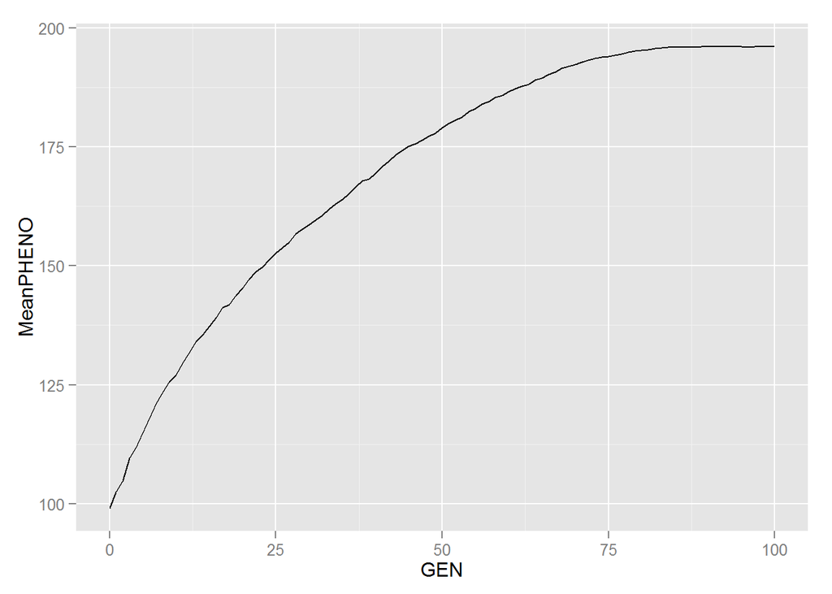

```r
df1 <- ddply(sim.1.res, .(GEN), summarise, MeanPHENO = mean(PHENO))
ggplot(df1, aes(GEN, MeanPHENO)) + geom_line()
```

The optimal phenotype that an individual can have in this case is 200. In this simulation, the maximum phenotype obtained is 196.03 and is reached in generation 100. Recombination can occur between all loci in this case and so it is possible to couple beneficial combinations of alleles.

*NB. One hypothesis to explain why recombination can be deleterious is that it can break up beneficial combinations of alleles that have already been built up by selection over time - but when selection is strong and directional, this not the case (although all variance in phenotype has disappeared).*

##### Variation in recombination rate.

What happens to the response to selection if recombination rates are increased? Let’s try a chromosome of 2 Morgans in length, but with the same number of loci.

```r
map.2  <- rep(2/n.loci, n.loci)
freq.2 <- rep(0.5, n.loci)

sim.2 <- simPopulationResponse(n.found.hap = n.found.hap,
                               n.loci = n.loci,
                               n.f = n.females, n.m = n.males,
                               map.list = list(map.2),
                               allele.freqs = freq.2,
                               f.RS = n.offspring,
                               sel.thresh.f = female.sel.thresh,
                               sel.thresh.m = male.sel.thresh,
                               n.generations = generations,
                               force.equal.male.success = T,
                               force.equal.sex = T,
                               progressBar = F)


sim.2.res <- rbindlist(sim.2$results)

sim.2.res
```

```
##        GEN  ID MOTHER FATHER SEX PHENO modifier Bred
##     1:   0   1     NA     NA   1    92        1    0
##     2:   0   2     NA     NA   1    87        1    0
##     3:   0   3     NA     NA   1   101        1    1
##     4:   0   4     NA     NA   1   105        1    1
##     5:   0   5     NA     NA   1    97        1    0
##    ---
## 10096: 100  96     96      7   2   200        1    1
## 10097: 100  97     98     37   1   200        1    1
## 10098: 100  98     98     35   2   200        1    1
## 10099: 100  99    100     29   1   200        1    1
## 10100: 100 100    100     99   2   200        1    1
```

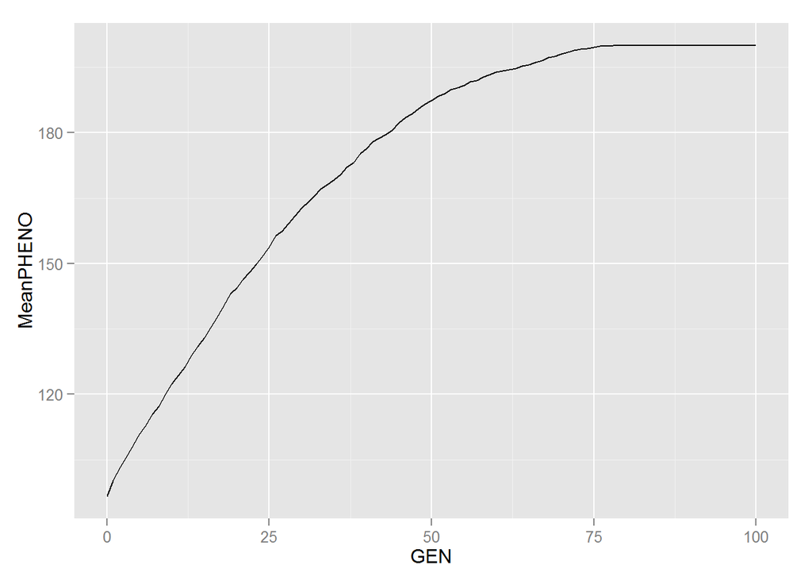

```r
df2 <- ddply(sim.2.res, .(GEN), summarise, MeanPHENO = mean(PHENO))

ggplot(df2, aes(GEN, MeanPHENO)) + geom_line()
```

In this case, the response to selection is faster, reaching a maximum value of 200 at generation 80

I can run the simulations multiple times and examine the mean outcome. The function `createFounderObject` can create a founder population that can be input repeatedly - e.g. if comparing recombination scenarios, then they can start from the same haplotypes.

```r
#~~ Create list objects in which to save the results

sim.1.res.list <- list()
sim.2.res.list <- list()

#~~ Specify number of iterations

generations <- 100
n.iterations <- 10

#~~ Run simulations
```

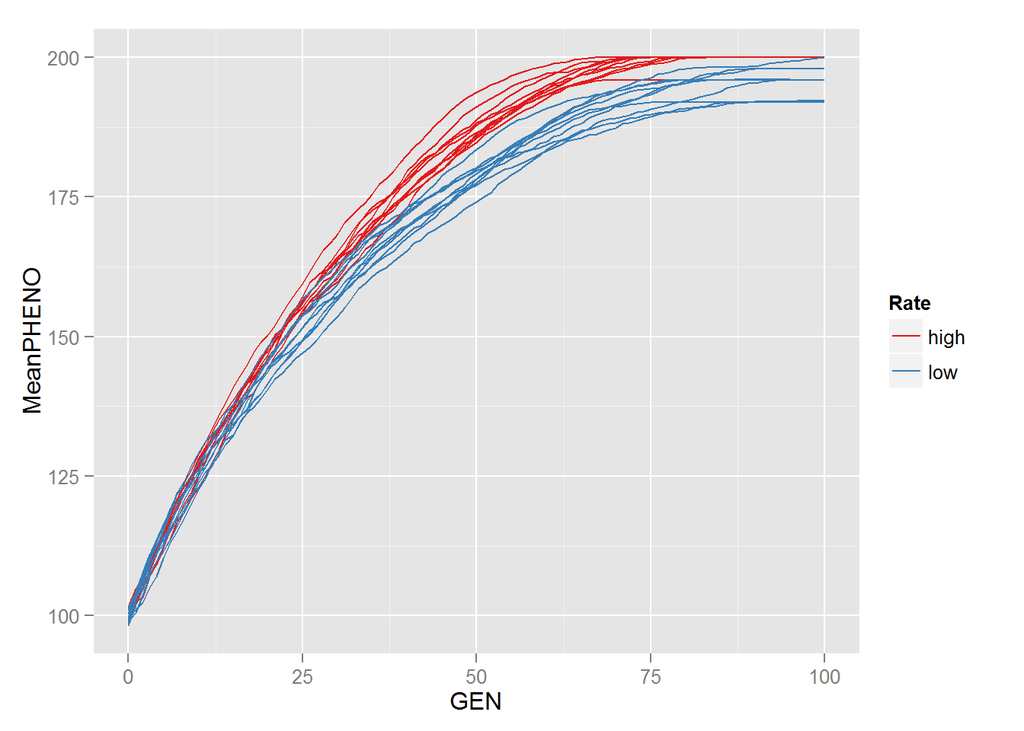

```r
if(SaveAndRunPrevModels == TRUE & file.exists(model.name)) {
  load(model.name)
  } else {

    for(i in 1:n.iterations){

      print(paste("Running iteration", i, "of", n.iterations))

      #~~ Create founder population
      founder.pop <- createFounderObject(allele.freqs = freq.1,
                                         n.found.hap = n.found.hap,
                                         n.loci = n.loci,
                                         n.f = n.females,
                                         n.m = n.males,
                                         f.RS = n.offspring)

      #~~ Simulate low recombination landscape

      sim.1.res.list[[i]] <- rbindlist(
        simPopulationResponse(n.found.hap = n.found.hap,
                              n.loci = n.loci, n.f = n.females,
                              n.m = n.males, map.list = list(map.1),
                              allele.freqs = freq.1,
                              f.RS = n.offspring,
                              sel.thresh.f = female.sel.thresh,
                              sel.thresh.m = male.sel.thresh,
                              n.generations = generations,
                              force.equal.male.success = T,
                              force.equal.sex = T,
                              progressBar = F,
                              FounderObject = founder.pop)$results)

      sim.1.res.list[[i]]$Simulation <- i
      sim.1.res.list[[i]]$Rate <- "low"



      #~~ Simulate high recombination landscape

      sim.2.res.list[[i]] <- rbindlist(
        simPopulationResponse(n.found.hap = n.found.hap,
                              n.loci = n.loci, n.f = n.females,
                              n.m = n.males, map.list = list(map.2),
                              allele.freqs = freq.2,
                              f.RS = n.offspring,
                              sel.thresh.f = female.sel.thresh,
                              sel.thresh.m = male.sel.thresh,
                              n.generations = generations,
                              force.equal.male.success = T,
                              force.equal.sex = T,
                              progressBar = F,
                              FounderObject = founder.pop)$results)

      sim.2.res.list[[i]]$Simulation <- i
      sim.2.res.list[[i]]$Rate <- "high"

      rm(founder.pop)
      }

    save(sim.1.res.list, sim.2.res.list, file = model.name)

    }

#~~ Parse output

sim.1.2 <- rbind(rbindlist(sim.1.res.list),
                 rbindlist(sim.2.res.list))

sim.1.2$Simulation <- as.factor(sim.1.2$Simulation)
sim.1.2$Rate       <- as.factor(sim.1.2$Rate)

setkey(sim.1.2, GEN, Rate, Simulation)


df1 <- ddply(sim.1.2, .(GEN, Rate, Simulation),
             summarise,
             MeanPHENO = mean(PHENO))

df2 <- ddply(sim.1.2, .(GEN, Rate),
             summarise,
             MeanPHENO = mean(PHENO))

ggplot(df1, aes(GEN, MeanPHENO,
                group = interaction(Simulation, Rate),
                colour = Rate)) +
  geom_line() +
  scale_colour_brewer(palette = "Set1")
```

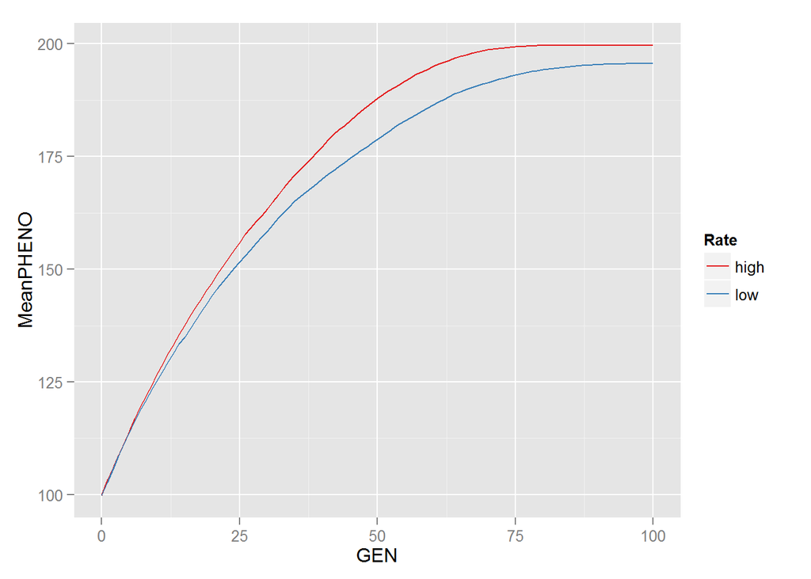

```r
ggplot(df2, aes(GEN, MeanPHENO, colour = Rate)) +
  geom_line() +
  scale_colour_brewer(palette = "Set1")
```

From above, it appears that higher recombination rates allows the population to respond to selection faster.

##### Polymorphism for a modifier locus that increases recombination rate.

Above, the two simulations were carried out in populations with fixed rates. With the `simPopulationResponse` function it is possible to specify the allele frequency of a modifier locus that affects recombination rates within the population. Two parameters are specified: the frequency of the modifier allele, B, in the population, and the recombination landscapes for homozygotes (AA), heterozygotes (AB) and homozygotes (BB), provided as a list of three vectors, in that order. For example, I will simulate a modifier that has an additive effect on recombination rate, doubling the rate between the two homozygotes, at a frequency of 0.5:

```r
increase.rate.freq <- 0.5

map.3 <- list(rep(1  /n.loci, n.loci),
              rep(1.5/n.loci, n.loci),
              rep(2  /n.loci, n.loci))
```

I now can simulate a population with a rate modifier:

```r
#~~ Specify number of iterations

generations <- 100
n.iterations <- 10
```

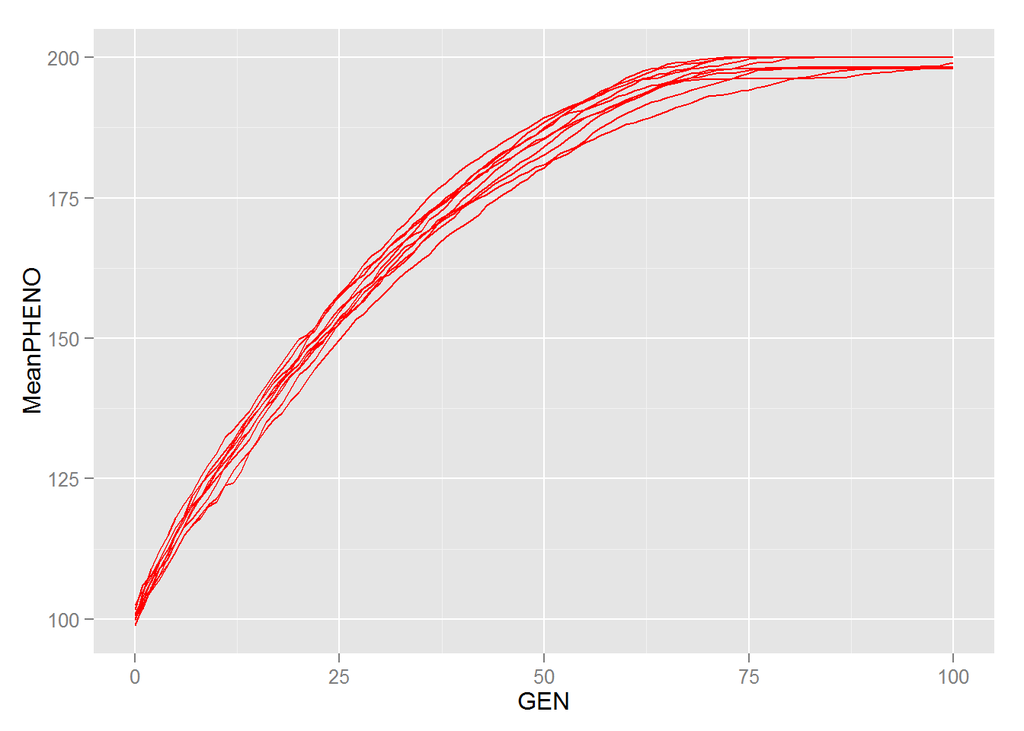

```r
#~~ Create list objects in which to save the results

sim.3.res.list <- list()


if(SaveAndRunPrevModels == T & file.exists(model.name3)){
  load(model.name3)
  } else {


    #~~ Run simulations

    for(i in 1:n.iterations){

      print(paste("Running iteration", i, "of", n.iterations))

      #~~ Simulate recombination landscape

      sim.3.res.list[[i]] <- rbindlist(
        simPopulationResponse(n.found.hap = n.found.hap,
                              n.loci = n.loci, n.f = n.females,
                              n.m = n.males, map.list = map.3,
                              allele.freqs = freq.1,
                              f.RS = n.offspring,
                              sel.thresh.f = female.sel.thresh,
                              sel.thresh.m = male.sel.thresh,
                              n.generations = generations,
                              modifier.found.freq = 0.5,
                              force.equal.male.success = T,
                              force.equal.sex = T,
                              progressBar = F)$results)

      sim.3.res.list[[i]]$Simulation <- i
      }
    save(sim.3.res.list, file = model.name3)
    }
#~~ Parse output

sim.3 <- rbindlist(sim.3.res.list)

sim.3$Simulation <- as.factor(sim.3$Simulation)

setkey(sim.3, GEN, Simulation)

mod.freq <- function(vec) {sum(vec - 1)/(2*length(vec))}


df1 <- ddply(sim.3, .(GEN, Simulation),
             summarise,
             MeanPHENO = mean(PHENO),
             ModifierFreq = mod.freq(modifier))

df2 <- ddply(sim.3, .(GEN),
             summarise,
             MeanPHENO = mean(PHENO),
             ModifierFreq = mod.freq(modifier))


ggplot(df1, aes(GEN, MeanPHENO, group = Simulation)) +
  geom_line(colour = "red")
```

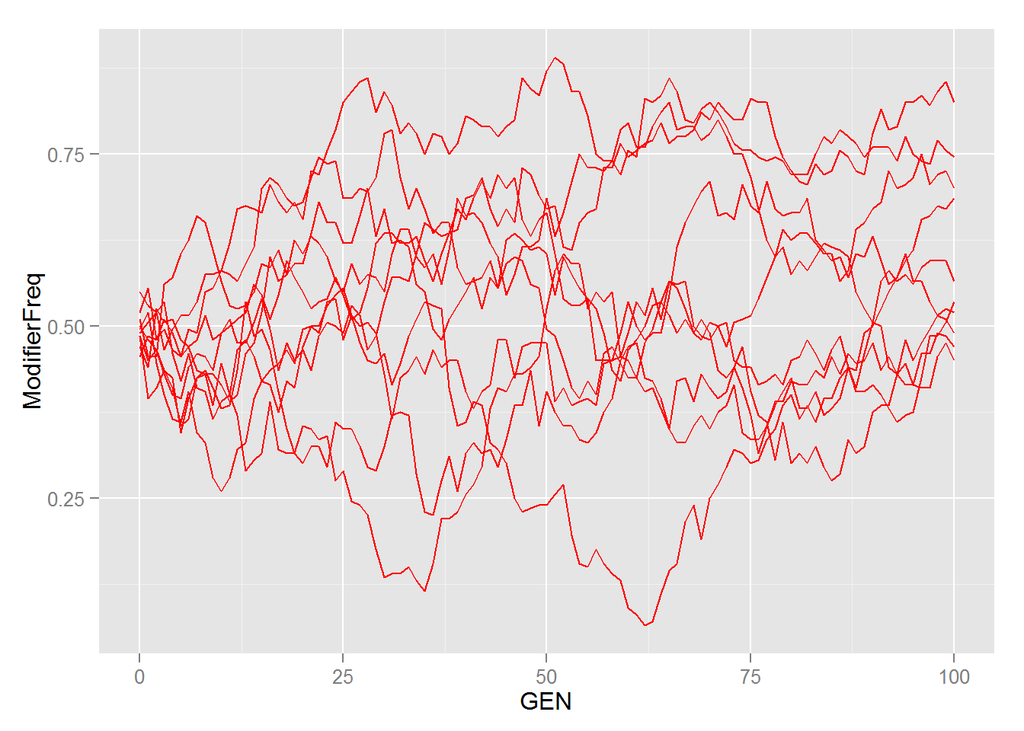

```r
ggplot(df1, aes(GEN, ModifierFreq, group = Simulation)) +
  geom_line(colour = "red")
```

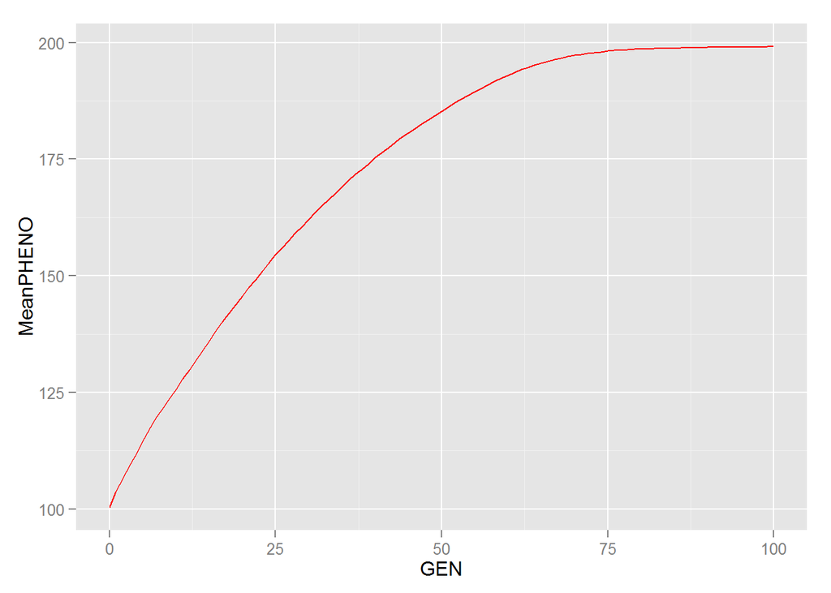

```r
ggplot(df2, aes(GEN, MeanPHENO)) +
  geom_line(colour = "red")
```

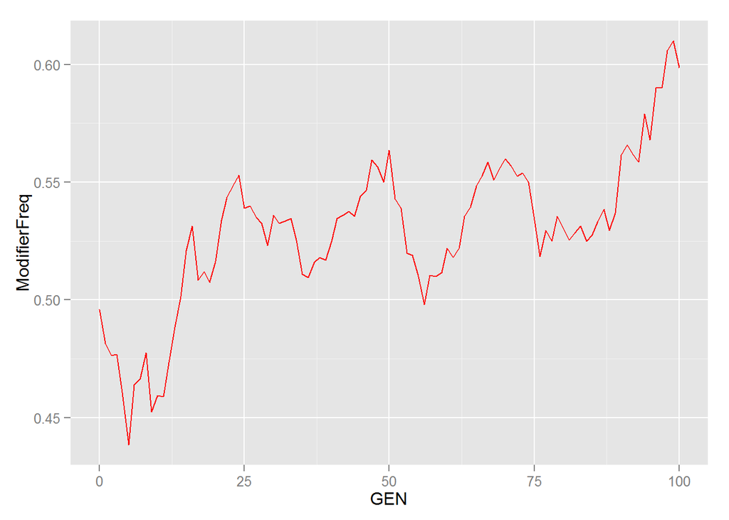

```r
ggplot(df2, aes(GEN, ModifierFreq)) +
  geom_line(colour = "red")
```

##### Mofidier that chanhes location of recombination

```r
increase.rate.freq <- 0.5

map.4 <- list(rep(c(0, 2/n.loci), length.out = n.loci),
              rep(1/n.loci, n.loci),
              rep(c(2/n.loci, 0), length.out = n.loci))
```

I now can simulate a population with a rate modifier:

```r
#~~ Specify number of iterations

generations <- 200
n.iterations <- 20
```

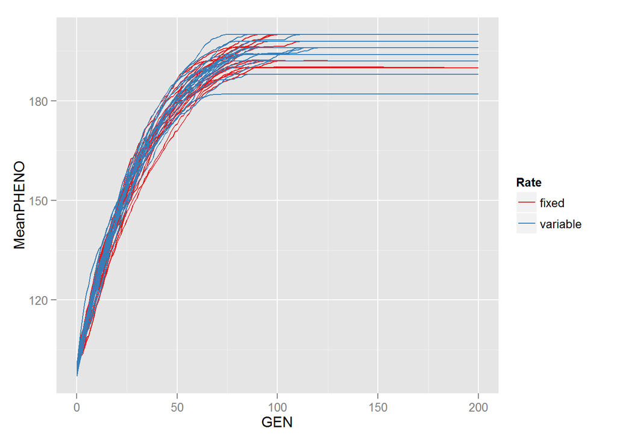

```r
#~~ Create list objects in which to save the results

sim.4.res.list <- list()
sim.4a.res.list <- list()


if(SaveAndRunPrevModels == T & file.exists(model.name4)){
  load(model.name4)
  } else {


    #~~ Run simulations

    for(i in 1:n.iterations){

      print(paste("Running iteration", i, "of", n.iterations))

      #~~ Simulate recombination landscape

      founder.pop <- createFounderObject(allele.freqs = freq.1,
                                         n.found.hap = n.found.hap,
                                         n.loci = n.loci,
                                         n.f = n.females,
                                         n.m = n.males,
                                         f.RS = n.offspring)



      sim.4.res.list[[i]] <- rbindlist(
        simPopulationResponse(n.found.hap = n.found.hap,
                              n.loci = n.loci, n.f = n.females,
                              n.m = n.males, map.list = map.4,
                              allele.freqs = freq.1,
                              f.RS = n.offspring,
                              sel.thresh.f = female.sel.thresh,
                              sel.thresh.m = male.sel.thresh,
                              n.generations = generations,
                              modifier.found.freq = 0,
                              force.equal.male.success = T,
                              force.equal.sex = T,
                              FounderObject = founder.pop,
                              progressBar = F)$results)

      sim.4.res.list[[i]]$Simulation <- i
      sim.4.res.list[[i]]$Rate <- "fixed"

      sim.4a.res.list[[i]] <- rbindlist(
        simPopulationResponse(n.found.hap = n.found.hap,
                              n.loci = n.loci, n.f = n.females,
                              n.m = n.males, map.list = map.4,
                              allele.freqs = freq.1,
                              f.RS = n.offspring,
                              sel.thresh.f = female.sel.thresh,
                              sel.thresh.m = male.sel.thresh,
                              n.generations = generations,
                              modifier.found.freq = 0.5,
                              force.equal.male.success = T,
                              force.equal.sex = T,
                              FounderObject = founder.pop,
                              progressBar = F)$results)

      sim.4a.res.list[[i]]$Simulation <- i
      sim.4a.res.list[[i]]$Rate <- "variable"



      }
    save(sim.4.res.list, sim.4a.res.list, file = model.name4)
    }
#~~ Parse output

sim.4 <- rbind(rbindlist(sim.4.res.list),
                 rbindlist(sim.4a.res.list))

sim.4$Simulation <- as.factor(sim.4$Simulation)
sim.4$Rate       <- as.factor(sim.4$Rate)

setkey(sim.4, GEN, Rate, Simulation)


df1 <- ddply(sim.4, .(GEN, Rate, Simulation),
             summarise,
             MeanPHENO = mean(PHENO),
             ModifierFreq = mod.freq(modifier))

df2 <- ddply(sim.4, .(GEN, Rate),
             summarise,
             MeanPHENO = mean(PHENO),
             ModifierFreq = mod.freq(modifier))

ggplot(df1, aes(GEN, MeanPHENO,
                group = interaction(Simulation, Rate),
                colour = Rate)) +
  geom_line() +
  scale_colour_brewer(palette = "Set1")
```

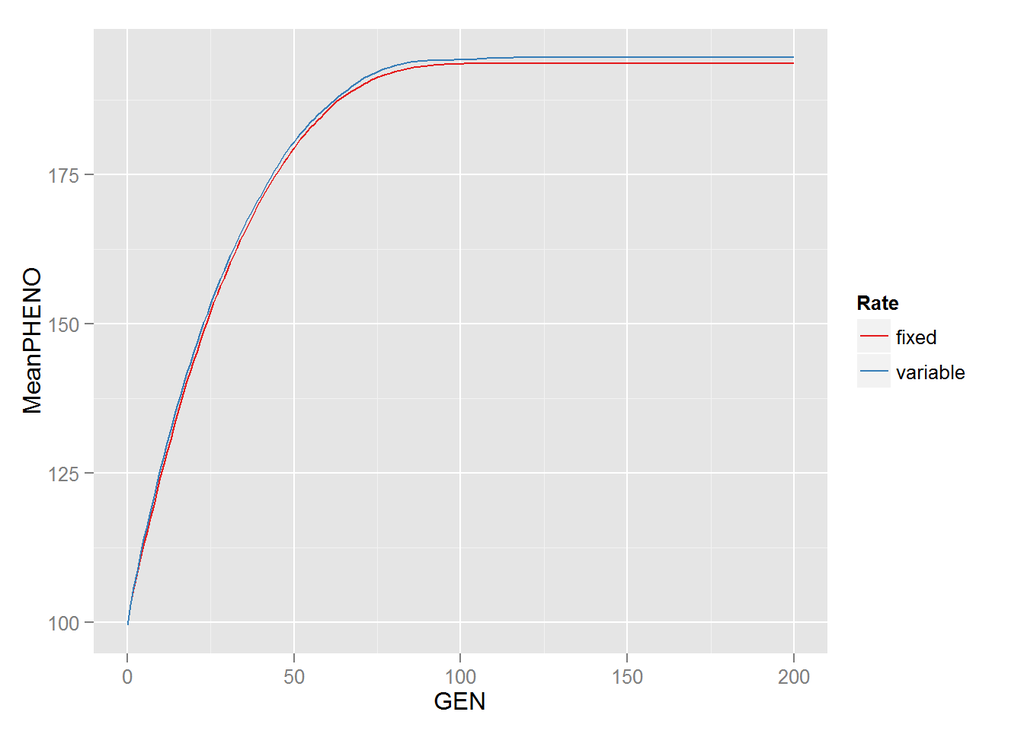

```r
ggplot(df2, aes(GEN, MeanPHENO, colour = Rate)) +
  geom_line() +
  scale_colour_brewer(palette = "Set1")
```

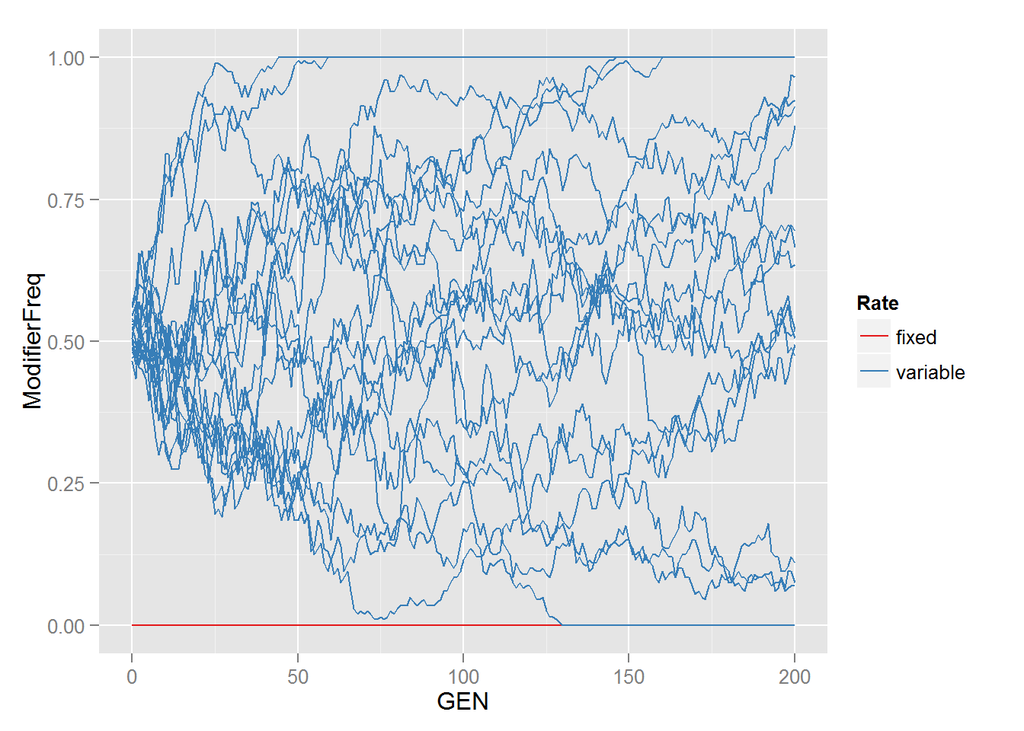

```r
ggplot(df1, aes(GEN, ModifierFreq, colour = Rate,
                group = interaction(Simulation, Rate))) +
  geom_line() +
  scale_colour_brewer(palette = "Set1")
```

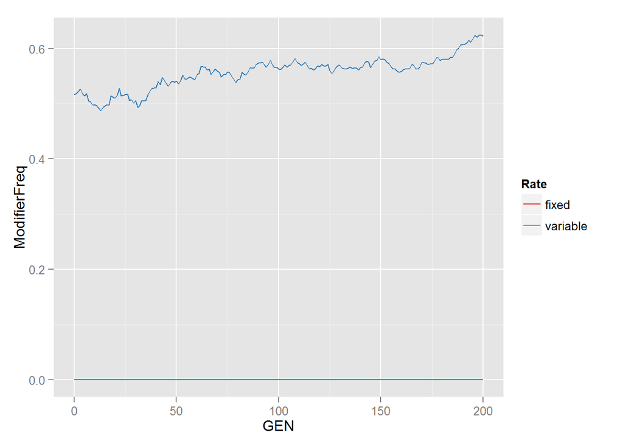

```r
ggplot(df2, aes(GEN, ModifierFreq, colour = Rate)) +
  geom_line() +
  scale_colour_brewer(palette = "Set1")
```